# Lab1

Nathaniel Gunter

1/13/2020

# Lab 1

## Task 1

Downloaded “DATAxls” and unzipped into LAB1. Then set the working directory by using the code:

```r
setwd("~/School/Junior Year/Spring/Applied Statistical Methods/Labs/LAB1/DATAxls")
```

Then obtain the working directory (to check) using:

```r
getwd()
```

```
## [1] "C:/Users/Nathaniel Gunter/Documents/School/Junior Year/Spring/Applied Statistical Methods/Labs/LAB1/DATAxls"
```

## Task 2

Saved DDT.xls as DDT.csv using Microsoft Excel. Read the data using:

```r
ddt = read.csv("DDT.csv")
```

Then check the first six lines using:

```r
head(ddt)
```

```
##   RIVER MILE  SPECIES LENGTH WEIGHT DDT
## 1   FCM    5 CCATFISH   42.5    732  10
## 2   FCM    5 CCATFISH   44.0    795  16
## 3   FCM    5 CCATFISH   41.5    547  23
## 4   FCM    5 CCATFISH   39.0    465  21
## 5   FCM    5 CCATFISH   50.5   1252  50
## 6   FCM    5 CCATFISH   52.0   1255 150
```

## Task 3

To better understand charactaristics of the data set, we use:

```r
knitr::kable(summary(ddt))
```

|  | RIVER | MILE | SPECIES | LENGTH | WEIGHT | DDT |
| --- | --- | --- | --- | --- | --- | --- |
|  | FCM: 6 | Min. : 1.0 | CCATFISH :96 | Min. :17.50 | Min. : 173.0 | Min. : 0.110 |
|  | LCM: 6 | 1st Qu.:283.8 | LMBASS :12 | 1st Qu.:40.50 | 1st Qu.: 805.5 | 1st Qu.: 3.375 |
|  | SCM: 6 | Median :300.0 | SMBUFFALO:36 | Median :45.00 | Median :1000.0 | Median : 7.150 |
|  | TRM:126 | Mean :268.6 | NA | Mean :42.81 | Mean :1049.7 | Mean : 24.355 |
|  | NA | 3rd Qu.:320.0 | NA | 3rd Qu.:47.50 | 3rd Qu.:1257.8 | 3rd Qu.: 13.000 |
|  | NA | Max. :345.0 | NA | Max. :52.00 | Max. :2302.0 | Max. :1100.000 |

From this summary, we see the following properties. The qualitative variables in ddt are RIVER and SPECIES. The quantitative variables are MILE, LENGTH, WEIGHT, and DDT. There are three different species in this data set.

Now we subset the data for SPECIES==LMBASS and WEIGHT larger than 800 grams:

```r
lmbass800 = with(ddt, ddt[SPECIES == 'LMBASS' & WEIGHT > 800,])
head(lmbass800)
```

```
##     RIVER MILE SPECIES LENGTH WEIGHT DDT
## 141   TRM  345  LMBASS     30    856 2.2
## 144   TRM  345  LMBASS     36   1433 1.9
```

Then subset the data for RIVER==SCM and DDT>4.0:

```r
scmddt = with(ddt, ddt[RIVER=='SCM' & DDT>4.0,])
head(scmddt)
```

```
##    RIVER MILE  SPECIES LENGTH WEIGHT DDT
## 16   SCM    1 CCATFISH     45    984 9.1
## 17   SCM    1 CCATFISH     43    965 7.8
## 18   SCM    1 CCATFISH     45   1084 4.1
```

```r
sd(ddt$WEIGHT,na.rm = FALSE)
```

```
## [1] 376.5461
```

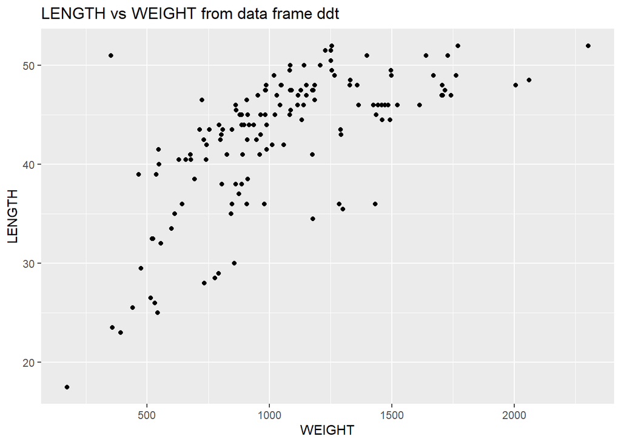

```r
ggplot(ddt, aes(x=WEIGHT, y=LENGTH))+geom_point()+ggtitle("LENGTH vs WEIGHT from data frame ddt")
```

Q.4: If v = 1:20 what is the last value of v/20?  
A.4: 1.00

## Task 4

Make a table of the rivers.

```r
table(ddt$RIVER)
```

```
##
## FCM LCM SCM TRM
##   6   6   6 126
```

Make a color coded barplot of the rivers.

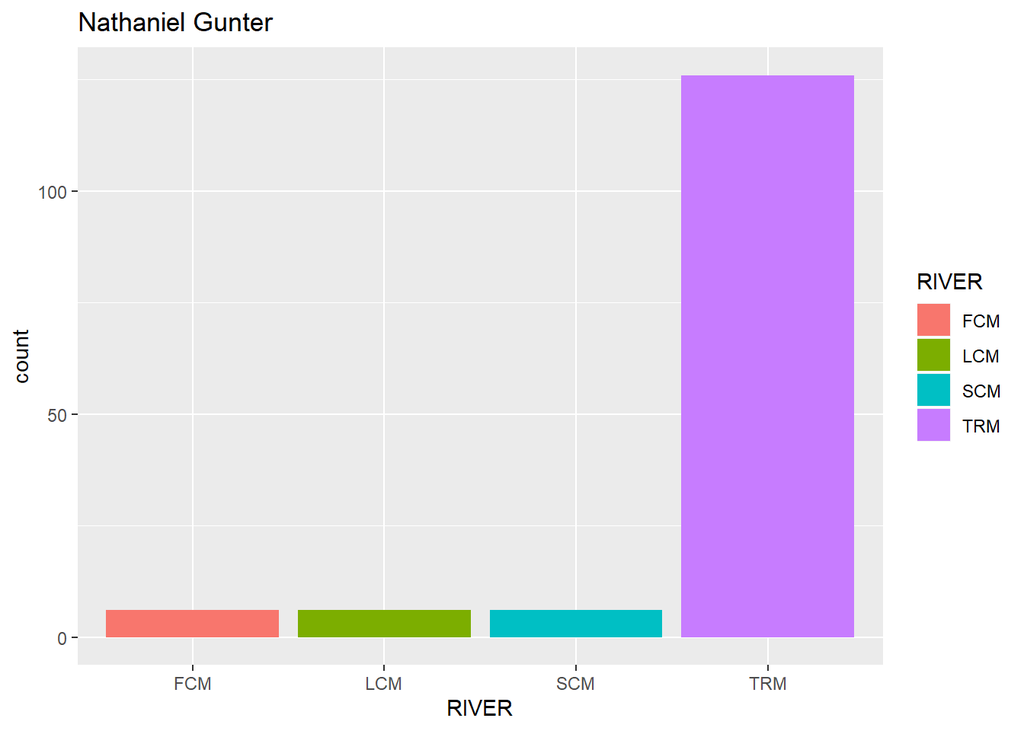

```r
ddt %>% ggplot(aes(x=RIVER, fill=RIVER))+geom_bar()+ggtitle("Nathaniel Gunter")
```

## Task 5

Make a pie chart of Fish SPECIES.

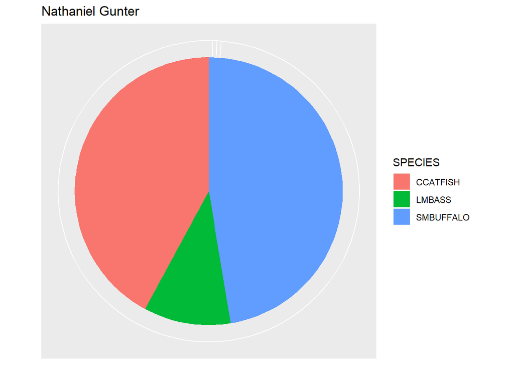

```r
speciesPie<- ddt%>%ggplot(aes(x="",y=SPECIES, fill = SPECIES), )+theme(axis.text.y = element_blank())+geom_bar(width=1, stat="identity")+ggtitle("Nathaniel Gunter") + theme(axis.text = element_blank(), axis.ticks=element_blank(), axis.title.x = element_blank(), axis.title.y=element_blank(), axis.line=element_blank())+coord_polar("y",start=0)
speciesPie
```

Make a pie chart of RIVERS.

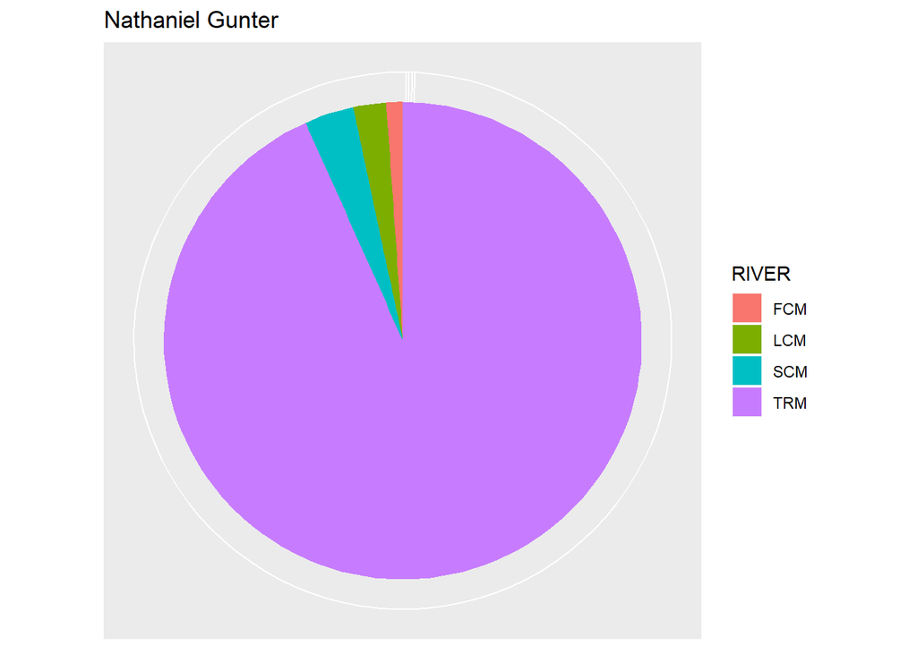

```r
riversPie <- ddt%>%ggplot(aes(x="",y=RIVER, fill=RIVER), )+geom_bar(width=1, stat="identity")+ggtitle("Nathaniel Gunter")+ theme(axis.text = element_blank(), axis.ticks=element_blank(), axis.title.x = element_blank(), axis.title.y=element_blank(),axis.line=element_blank())+coord_polar("y",start=0)
riversPie
```

## Task 6

Make a boxplot of the variable DDT.

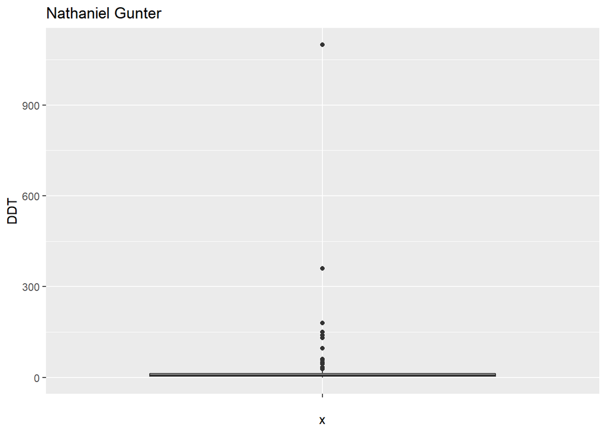

```r
ddtbox <- ddt%>%ggplot(aes(x = "",y=DDT),)+geom_boxplot()+ggtitle("Nathaniel Gunter")
ddtbox
```

Make a boxplot of the variable WEIGHT.

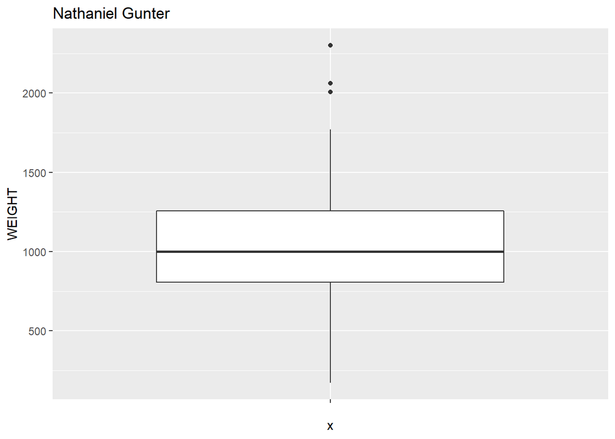

```r
weightbox <- ddt%>%ggplot(aes(x = "", y = WEIGHT),)+geom_boxplot()+ggtitle("Nathaniel Gunter")
weightbox
```

Make a boxplot of the variable LENGTH.

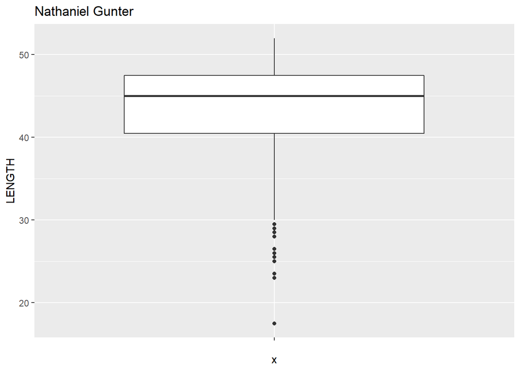

```r
lenbox <- ddt%>%ggplot(aes(x="",y=LENGTH),)+geom_boxplot()+ggtitle("Nathaniel Gunter")
lenbox
```

## Task 7

Make a coplot of LENGTH vs. WEIGHT given RIVER.

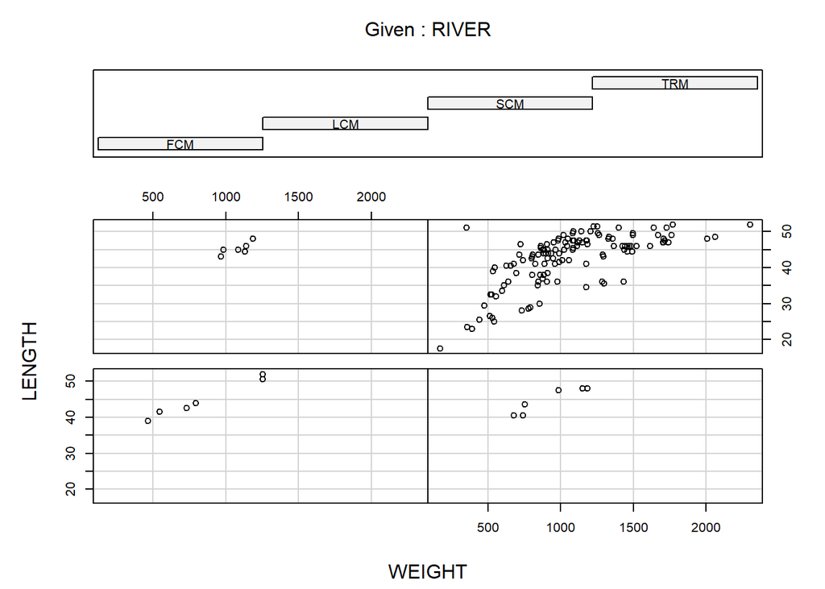

```r
coplot(LENGTH ~ WEIGHT | RIVER, data = ddt)
```

Make a coplot of DDT vs. WEIGHT given SPECIES.

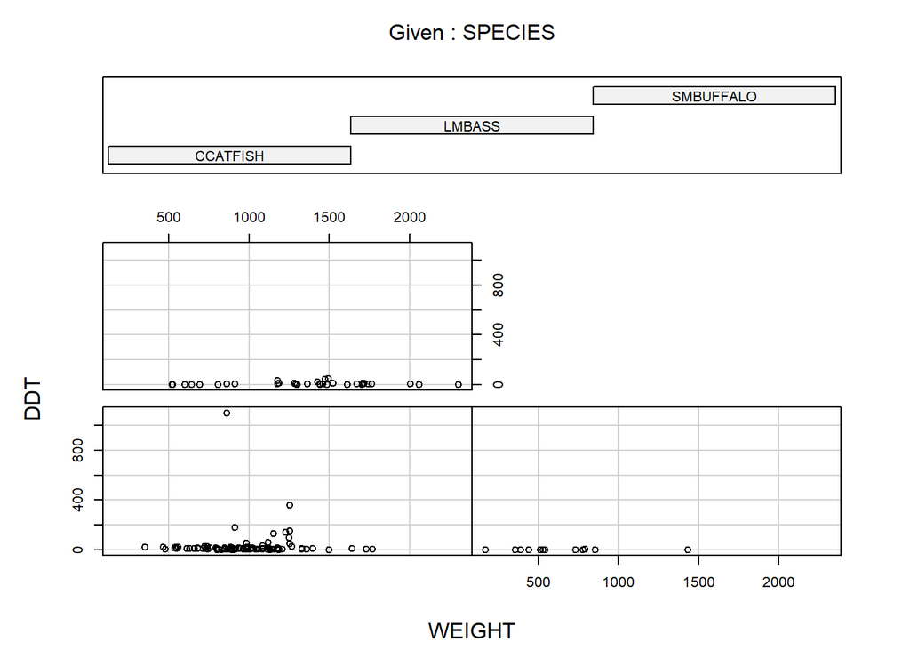

```r
coplot(DDT ~ WEIGHT | SPECIES, data = ddt)
```

## Task 8

Make the following boxplots using ‘ggplot’.

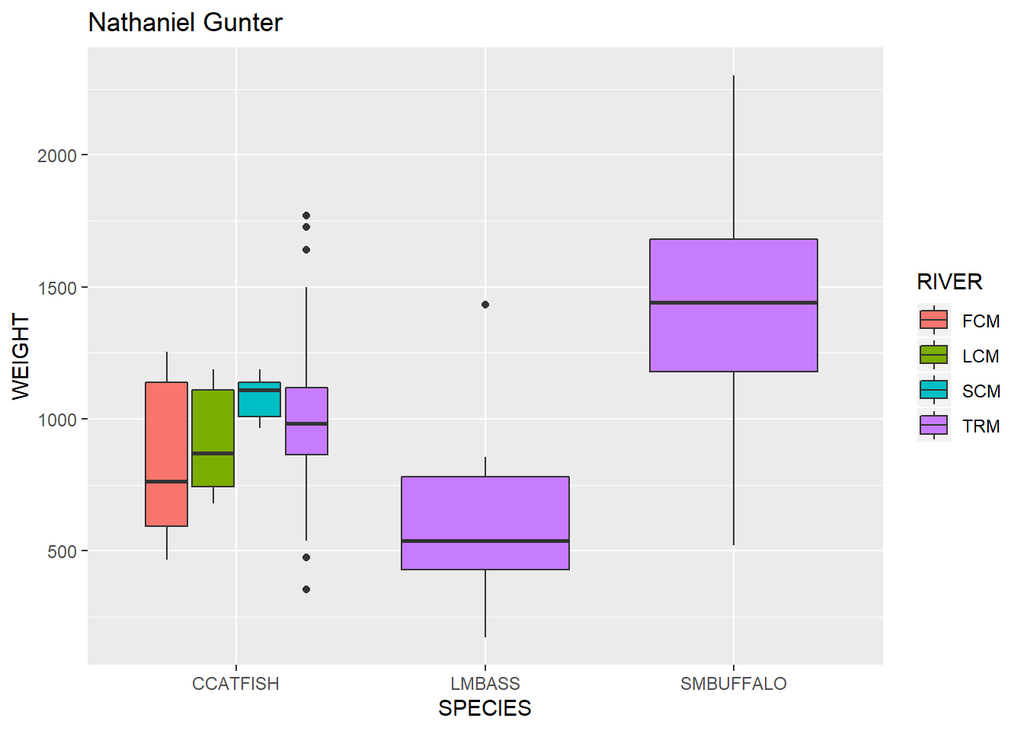

```r
boxplots <- ddt%>%ggplot(aes(x=SPECIES, y=WEIGHT, fill=RIVER))+geom_boxplot()+ggtitle("Nathaniel Gunter")
boxplots
```

Make the following violin plots.

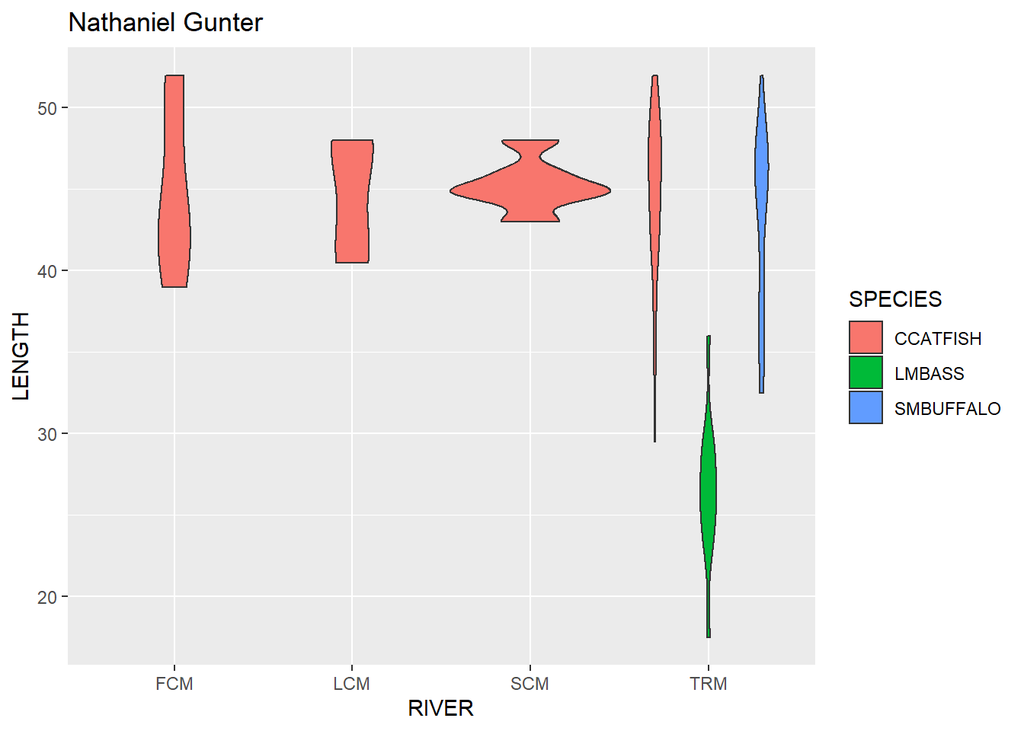

```r
violinplots <-ddt%>%ggplot(aes(x=RIVER,y=LENGTH,fill=SPECIES))+geom_violin()+ggtitle("Nathaniel Gunter")
violinplots
```

Make the following scatter plots.

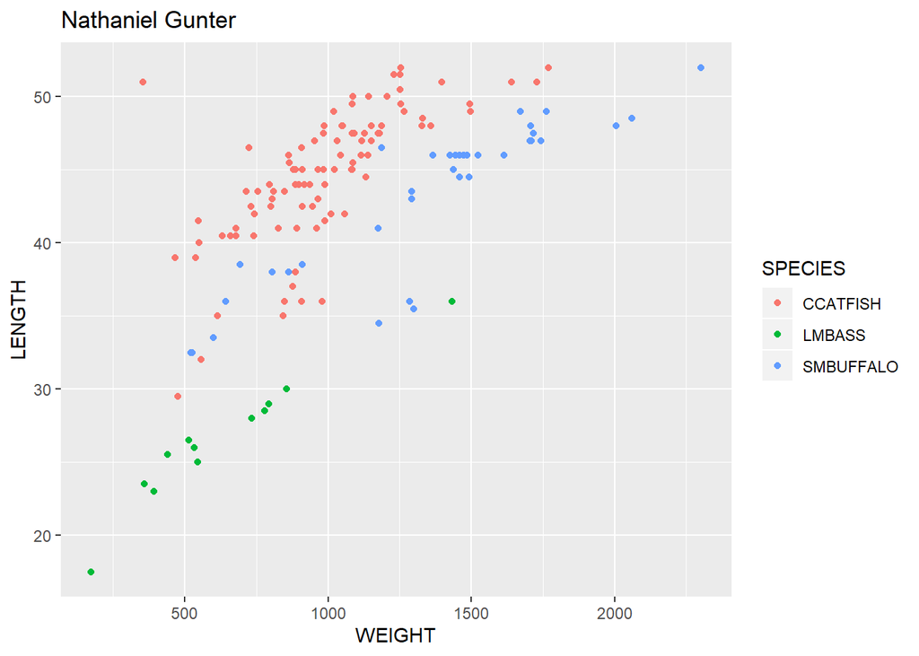

```r
scatterplots<-ddt%>%ggplot(aes(x=WEIGHT,y=LENGTH,colour=SPECIES))+geom_point()+ggtitle("Nathaniel Gunter")
scatterplots
```